# Final Project: R Reference

### How to create four panel plots

Put par(mfrow = ) BEFORE your plotting code * Set mfrow = c(# of rows, # of columns)

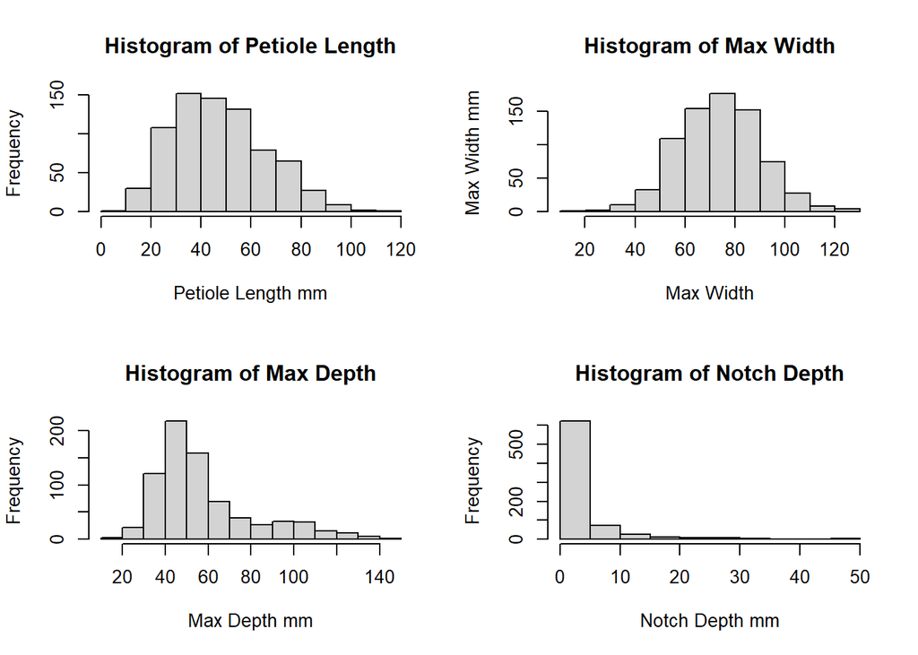

```r
par(mfrow = c(2,2))
hist(gingko$petiole_length,
     main = "Histogram of Petiole Length",
     xlab = "Petiole Length mm",
     ylab = "Frequency")
hist(gingko$max_width,
     main = "Histogram of Max Width",
     xlab = "Max Width",
     ylab = "Max Width mm")
hist(gingko$max_depth,
     main = "Histogram of Max Depth",
     xlab = "Max Depth mm",
     ylab = "Frequency")
hist(gingko$notch_depth,
     main = "Histogram of Notch Depth",
     xlab = "Notch Depth mm",
     ylab = "Frequency")
```

## Distribution Functions

The first 3 functions are associated with $normal distributions. These functions use continuous distributions, so the term is “density”

The second 3 functions are associated with $binomial distributions. These functions use discrete distribution, so the term is “mass”

### dnorm()

Used to obtain the value of a Probability Density Function at a certain number

- aka, how often did x occur in this distribution?

arguments:

- x = entered number value
- mean = default of 0
- sd = default of 1

```r
dnorm(0)
```

```
## [1] 0.3989423
```

### pnorm()

Cumulative Density Function

- aka, probability observing a value at or below x. To observe above x, use 1 - pnorm()

```r
pnorm(5, 5, 3)
```

```
## [1] 0.5
```

### qnorm()

Quantile Function

- Gives the x value that indicates a certain percentile

```r
qnorm(0.5, 10, 5)
```

```
## [1] 10
```

```r
qnorm(c(0.025, 0.975))
```

```
## [1] -1.959964  1.959964
```

### dbinom()

- used to find probability of observing x number of successes

arguments: * x = number of successes * size = number of trials * prob = probability of success for each trial

```r
dbinom(
  x = 3,
  size = 6,
  prob = .4)
```

```
## [1] 0.27648
```

### pbinom()

Cumulative Density Function

- used to observe the probability of observing a value of x or less/or more

arguments: * q = random variable * size = number of trials * prob = probability of success for each trial * lower.tail = TRUE or FALSe. If you’re looking to the right of q, use FALSE. to the left, use TRUE.

```r
pbinom(q = 3,
       size = 10,
       prob = 0.5,
       lower.tail = FALSE)
```

```
## [1] 0.828125
```

### qbinom()

Quantile Density Function

- Used to observe quantiles (i.e. 50th quantile, 90th quantile) where q is the quantile

```r
qbinom(.50,
       size = 12,
       prob = .6)
```

```
## [1] 7
```

```r
#The 50th quantile occurs at 7
```